# Project5

Creating data from digital sources

Yuekun Yao

2024-05-21

## Part A

I explored the difference and similarity of popular movies in theaters and streaming, and I will pay attention to movies title, movies year, movies critics consensus, movies director, and movies synopsis.

I chose to explore the data context, since I want to find some similarities or creative elements in some good popular movies.

```r
library(tidyverse)
library(rvest)
library(magick)

# My data context is the difference and similarity of popular movies in theaters and streaming.

# Movies title, year, critics consensus, synopsis and director are useful for my exploration.

# I used to try  https://www.netflix.com/tudum/top10/, however it is not appropriate for web scraping.
# Since, by checking the terms and conditions and reading the "robots.txt" file of the websit, I found the website is not allowed to use any robot, spider, scraper or other automated means to access the Website.

url <- "https://editorial.rottentomatoes.com/guide/popular-movies/"
page <- read_html(url)

# movies title
movie_title <- page %>%
  html_elements(".articleContentBody")%>%
  html_elements("h2")%>%
  html_elements("a")%>%
  html_text2()
movie_title
```

```
##  [1] "IF"
##  [2] "Kingdom of the Planet of the Apes"
##  [3] "The Strangers: Chapter 1"
##  [4] "The Last Stop in Yuma County"
##  [5] "Challengers"
##  [6] "The Fall Guy"
##  [7] "Back to Black"
##  [8] "Madame Web"
##  [9] "The Idea of You"
## [10] "The Ministry of Ungentlemanly Warfare"
## [11] "War for the Planet of the Apes"
## [12] "Abigail"
## [13] "Godzilla x Kong: The New Empire"
## [14] "I Saw the TV Glow"
## [15] "Babes"
## [16] "Civil War"
## [17] "Mother of the Bride"
## [18] "Tarot"
## [19] "Late Night with the Devil"
## [20] "Unfrosted"
## [21] "The Iron Claw"
## [22] "LaRoy, Texas"
## [23] "Rise of the Planet of the Apes"
## [24] "Monkey Man"
## [25] "Planet of the Apes"
## [26] "Dawn of the Planet of the Apes"
## [27] "Dark Waters"
## [28] "Mad Max: Fury Road"
## [29] "Sting"
## [30] "Anyone But You"
```

```r
#movies year
movie_year <- page %>%
  html_elements(".countdown-item-content") %>%
  html_elements(".subtle.start-year") %>%
  html_text(trim = TRUE) %>%
  gsub("\\D", "", .)
movie_year
```

```
##  [1] "2024" "2024" "2024" "2023" "2024" "2024" "2024" "2024" "2024" "2024"
## [11] "2017" "2024" "2024" "2024" "2024" "2024" "2024" "2024" "2023" "2024"
## [21] "2023" "2023" "2011" "2024" "1968" "2014" "2019" "2015" "2024" "2023"
```

```r
#movies url
movie_url <- page %>%
  html_elements(".article_movie_title")%>%
  html_elements("a")%>%
  html_attr("href")
movie_url
```

```
##  [1] "https://www.rottentomatoes.com/m/if_2024"
##  [2] "https://www.rottentomatoes.com/m/kingdom_of_the_planet_of_the_apes"
##  [3] "https://www.rottentomatoes.com/m/the_strangers_chapter_1"
##  [4] "https://www.rottentomatoes.com/m/the_last_stop_in_yuma_county"
##  [5] "https://www.rottentomatoes.com/m/challengers_2024"
##  [6] "https://www.rottentomatoes.com/m/the_fall_guy_2024"
##  [7] "https://www.rottentomatoes.com/m/back_to_black"
##  [8] "https://www.rottentomatoes.com/m/madame_web"
##  [9] "https://www.rottentomatoes.com/m/the_idea_of_you"
## [10] "https://www.rottentomatoes.com/m/the_ministry_of_ungentlemanly_warfare"
## [11] "https://www.rottentomatoes.com/m/war_for_the_planet_of_the_apes"
## [12] "https://www.rottentomatoes.com/m/abigail_2024"
## [13] "https://www.rottentomatoes.com/m/godzilla_x_kong_the_new_empire"
## [14] "https://www.rottentomatoes.com/m/i_saw_the_tv_glow"
## [15] "https://www.rottentomatoes.com/m/babes"
## [16] "https://www.rottentomatoes.com/m/civil_war_2024"
## [17] "https://www.rottentomatoes.com/m/mother_of_the_bride_2024"
## [18] "https://www.rottentomatoes.com/m/tarot_2024"
## [19] "https://www.rottentomatoes.com/m/late_night_with_the_devil"
## [20] "https://www.rottentomatoes.com/m/unfrosted"
## [21] "https://www.rottentomatoes.com/m/the_iron_claw_2023"
## [22] "https://www.rottentomatoes.com/m/laroy_texas"
## [23] "https://www.rottentomatoes.com/m/rise_of_the_planet_of_the_apes"
## [24] "https://www.rottentomatoes.com/m/monkey_man"
## [25] "https://www.rottentomatoes.com/m/1016397-planet_of_the_apes"
## [26] "https://www.rottentomatoes.com/m/dawn_of_the_planet_of_the_apes"
## [27] "https://www.rottentomatoes.com/m/dark_waters_2019"
## [28] "https://www.rottentomatoes.com/m/mad_max_fury_road"
## [29] "https://www.rottentomatoes.com/m/sting"
## [30] "https://www.rottentomatoes.com/m/anyone_but_you_2023"
```

```r
#movies director
movie_director <- page %>%
  html_elements(".countdown-item-content .info.director") %>%
  html_text2()%>%
  str_replace_all("Directed By: ", "")
movie_director
```

```
##  [1] "John Krasinski"
##  [2] "Wes Ball"
##  [3] "Renny Harlin"
##  [4] "Francis Galluppi"
##  [5] "Luca Guadagnino"
##  [6] "David Leitch"
##  [7] "Sam Taylor-Johnson"
##  [8] "S.J. Clarkson"
##  [9] "Michael Showalter"
## [10] "Guy Ritchie"
## [11] "Matt Reeves"
## [12] "Matt Bettinelli-Olpin, Tyler Gillett"
## [13] "Adam Wingard"
## [14] "Jane Schoenbrun"
## [15] "Pamela Adlon"
## [16] "Alex Garland"
## [17] "Mark Waters"
## [18] "Spenser Cohen, Anna Halberg"
## [19] "Colin Cairnes, Cameron Cairnes"
## [20] "Jerry Seinfeld"
## [21] "Sean Durkin"
## [22] "Shane Atkinson"
## [23] "Rupert Wyatt"
## [24] "Dev Patel"
## [25] "Franklin J. Schaffner"
## [26] "Matt Reeves"
## [27] "Todd Haynes"
## [28] "George Miller"
## [29] "Kiah Roache-Turner"
## [30] "Will Gluck"
```

```r
# movies critics consensus
movie_consensus <- page %>%
  html_elements(".critics-consensus") %>%
  html_text2()
movie_consensus
```

```
##  [1] "Critics Consensus: A sweet ode to rediscovering one's inner child, IF largely works as old-fashioned family entertainment despite an occasionally unfocused and unnecessarily complicated plot."
##  [2] "Critics Consensus: Carving out a new era for The Planet of the Apes with lovable characters and rich visuals, Kingdom doesn't take the crown as best of the franchise but handily justifies its continued reign."
##  [3] "Critics Consensus: Lacking the chilling suspense of the original The Strangers and proving to be just unpleasant, this Chapter 1 closes the book on itself."
##  [4] "Critics Consensus: A smart, tautly constructed crime thriller with some fresh twists, The Last Stop in Yuma County marks writer-director Francis Galluppi as a talent to watch."
##  [5] "Critics Consensus: With its trio of outstanding performers volleying their star power back and forth without ever dropping the ball, Challengers is a kinetic and sexy romp at court."
##  [6] "Critics Consensus: With action, comedy, romance, and a pair of marvelously matched stars, The Fall Guy might be the rare mainstream movie with something to entertain everyone."
##  [7] "Critics Consensus: Back to Black's sympathetic approach to its subject's story is an overdue antidote to the tabloid treatment she often received in life, even if the end results are disappointingly pedestrian."
##  [8] "Critics Consensus: Madame Web's earnest approach to the title character's origin story has a certain appeal, but its predictable plot and uneven execution make for a forgettable superhero adventure."
##  [9] "Critics Consensus: The Idea of You offers a welcome reminder that Anne Hathaway remains a thoroughly delightful romcom lead -- and reaffirms that few filmmakers understand the genre better than Michael Showalter."
## [10] "Critics Consensus: Cranking up a true story of derring-do into a high-octane action flick that's heavy on spectacle if not suspense, The Ministry of Ungentlemanly Warfare is another solid entry into Guy Ritchie's pantheon."
## [11] "Critics Consensus: War for the Planet of the Apes combines breathtaking special effects and a powerful, poignant narrative to conclude this rebooted trilogy on a powerful -- and truly blockbuster -- note."
## [12] "Critics Consensus: Carrying off well-worn vampire tropes with a balletic flourish, Abigail dances around the familiarity of its premise with a game cast and slick style."
## [13] "Critics Consensus: Come to Godzilla x Kong: The New Empire for the sheer monster-mashing spectacle -- and stay for that too, because the movie doesn't have much else to offer."
## [14] "Critics Consensus: With a distinctive visual aesthetic that enhances its emotionally resonant narrative, I Saw the TV Glow further establishes writer-director Jane Schoenbrun as a rising talent."
## [15] "Critics Consensus: Offering an uproariously unvarnished look at motherhood and female friendships, Babes finds Pamela Adlon making an assured feature-length directorial debut with a big assist from stars Ilana Glazer and Michelle Buteau."
## [16] "Critics Consensus: Tough and unsettling by design, Civil War is a gripping close-up look at the violent uncertainty of life in a nation in crisis."
## [17] "Critics Consensus: No consensus yet."
## [18] "Critics Consensus: No consensus yet."
## [19] "Critics Consensus: Delightfully dark, Late Night with the Devil proves possession horror isn't played out -- and serves as an outstanding showcase for David Dastmalchian."
## [20] "Critics Consensus: Much like a preservative-packed toaster pastry, Unfrosted is sweet and colorful, yet it's ultimately an empty experience that may leave the consumer feeling pangs of regret."
## [21] "Critics Consensus: Powerfully acted and profoundly sad, The Iron Claw honors its fact-based story with a dramatization whose compassionate exploration of family ties is just as hard-hitting as its action in the wrestling ring."
## [22] "Critics Consensus: Distinguished by sharp writing and a talented cast, LaRoy, Texas is a generally satisfying neo-noir treat for crime thriller fans."
## [23] "Critics Consensus: Led by Rupert Wyatt's stylish direction, some impressive special effects, and a mesmerizing performance by Andy Serkis, Rise of the Planet of the Apes breathes unlikely new life into a long-running franchise."
## [24] "Critics Consensus: An audacious effort from debuting director Dev Patel, Monkey Man dispenses action and sociopolitical commentary with equal aplomb."
## [25] "Critics Consensus: Planet of the Apes raises thought-provoking questions about our culture without letting social commentary get in the way of the drama and action."
## [26] "Critics Consensus: With intelligence and emotional resonance to match its stunning special effects, Dawn of the Planet of the Apes expands on its predecessor with an exciting and ambitious burst of sci-fi achievement."
## [27] "Critics Consensus: Dark Waters powerfully relays a real-life tale of infuriating malfeasance, honoring the victims and laying blame squarely at the feet of the perpetrators."
## [28] "Critics Consensus: With exhilarating action and a surprising amount of narrative heft, Mad Max: Fury Road brings George Miller's post-apocalyptic franchise roaring vigorously back to life."
## [29] "Critics Consensus: Sting should satisfy horror fans in the mood for a creature feature, even if the end results likely won't linger in the memory."
## [30] "Critics Consensus: Slick direction and a pair of tremendously watchable stars make Anyone But You a passably fizzy diversion despite a less than scintillating story."
```

```r
# movies synopsis
movie_synopsis <- page %>%
  html_elements(".info.synopsis") %>%
  html_text2()
movie_synopsis
```

```
##  [1] "Synopsis: From writer and director John Krasinski, IF is about a girl who discovers that she can see everyone's imaginary friends... [More]"
##  [2] "Synopsis: Director Wes Ball breathes new life into the global, epic franchise set several generations in the future following Caesar's reign,... [More]"
##  [3] "Synopsis: After their car breaks down in an eerie small town, a young couple (Madelaine Petsch and Froy Gutierrez) are forced... [More]"
##  [4] "Synopsis: While awaiting the next fuel truck at a middle-of-nowhere Arizona rest stop, a traveling young knife salesman is thrust into... [More]"
##  [5] "Synopsis: From visionary filmmaker Luca Guadagnino, Challengers stars Zendaya as Tashi Duncan, a former tennis prodigy turned coach and a force... [More]"
##  [6] "Synopsis: He's a stuntman, and like everyone in the stunt community, he gets blown up, shot, crashed, thrown through windows and... [More]"
##  [7] "Synopsis: The extraordinary story of Amy Winehouse's early rise to fame and the making of her groundbreaking album, Back to Black.... [More]"
##  [8] "Synopsis: In a switch from the typical genre, Madame Web tells the standalone origin story of one of Marvel publishing's most... [More]"
##  [9] "Synopsis: Based on the acclaimed, contemporary love story of the same name, The Idea of You centers on Solène (Anne Hathaway),... [More]"
## [10] "Synopsis: Based upon recently declassified files of the British War Department and inspired by true events, THE MINISTRY OF UNGENTLEMANLY WARFARE... [More]"
## [11] "Synopsis: Caesar (Andy Serkis) and his apes are forced into a deadly conflict with an army of humans led by a... [More]"
## [12] "Synopsis: After a group of would-be criminals kidnap the 12-year-old ballerina daughter of a powerful underworld figure, all they have to... [More]"
## [13] "Synopsis: This latest entry in the Monsterverse franchise follows up the explosive showdown of Godzilla vs. Kong with an all-new cinematic... [More]"
## [14] "Synopsis: Teenager Owen is just trying to make it through life in the suburbs when his classmate introduces him to a... [More]"
## [15] "Synopsis: BABES follows inseparable childhood friends Eden (Ilana Glazer) and Dawn (Michelle Buteau), having grown up together in NYC, now firmly... [More]"
## [16] "Synopsis: From filmmaker Alex Garland comes a journey across a dystopian future America, following a team of military-embedded journalists as they... [More]"
## [17] "Synopsis: Lana's daughter Emma returns from abroad and drops a bombshell: she's getting married. In Thailand. In a month! Things only... [More]"
## [18] "Synopsis: When a group of friends recklessly violates the sacred rule of Tarot readings -- never use someone else's deck --... [More]"
## [19] "Synopsis: Johnny Carson rival Jack Delroy hosts a syndicated talk show 'Night Owls' that has long been a trusted companion to... [More]"
## [20] "Synopsis: Michigan, 1963. Kellogg's and Post, sworn cereal rivals, race to create a pastry that will change the face of breakfast... [More]"
## [21] "Synopsis: The true story of the inseparable Von Erich brothers, who made history in the intensely competitive world of professional wrestling... [More]"
## [22] "Synopsis: Broke and depressed, Ray (John Magaro) is mistaken for a dangerous hitman and given an envelope of cash. Along with... [More]"
## [23] "Synopsis: Will Rodman (James Franco), a scientist in San Francisco, is experimenting with a drug that he hopes will cure his... [More]"
## [24] "Synopsis: Inspired by the legend of Hanuman, an icon embodying strength and courage, Monkey Man stars Dev Patel as Kid, an... [More]"
## [25] "Synopsis: Complex sociological themes run through this science-fiction classic about three astronauts marooned on a futuristic planet where apes rule and... [More]"
## [26] "Synopsis: Ten years after simian flu wiped out much of the world's homosapiens, genetically enhanced chimpanzee Caesar (Andy Serkis) and his... [More]"
## [27] "Synopsis: A tenacious attorney uncovers a dark secret that connects a growing number of unexplained deaths to one of the world's... [More]"
## [28] "Synopsis: Years after the collapse of civilization, the tyrannical Immortan Joe enslaves apocalypse survivors inside the desert fortress the Citadel. When... [More]"
## [29] "Synopsis: STING spins a web of thrilling terror when 12-year-old Charlotte's pet spider rapidly transforms into a giant flesh-eating monster, forcing... [More]"
## [30] "Synopsis: In the edgy comedy Anyone But You, Bea (Sydney Sweeney) and Ben (Glen Powell) look like the perfect couple, but... [More]"
```

## Part B

```r
library(tidyverse)
library(rvest)
library(magick)

# I explored the releases published by Hon David Seymour.

#Features of text:The mean title words count is around 6.68
#The mean word count per release is around 384.05.
#The mean word count used per sentence in each release is around 23.28.
#The 15 most common words in release titles, sorted by frequency, are: government, attendance, new, school, ahead, back, charter, lift, medicines, plan, pseudoephedrine, rates, schools, shelves, and should.

# Obtain a vector of the URLs for each release listed on the minister’s page
url <- "https://www.beehive.govt.nz/minister/hon-david-seymour"

pages <- read_html(url) %>%
  html_elements(".release__wrapper") %>%
  html_elements("h2") %>%
  html_elements("a") %>%
  html_attr("href") %>%
  paste0("https://www.beehive.govt.nz", .)

# Scraping the title and the content of the first release
page_url <- pages[1]

page <- read_html(page_url)

release_title <- page %>%
  html_elements(".article__title") %>%
  html_text2()
release_title

release_content <- page  %>%
  html_elements(".prose.field.field--name-body.field--type-text-with-summary.field--label-hidden.field--item") %>%
  html_text2()
release_content

# Creating a function of get_release
get_release <- function(page_url){
  Sys.sleep(2)
  # print the page_url so if things go wrong
  # we can see which page caused issues
  print(page_url)
  page <- read_html(page_url)

  # add code to scrape the release title and release content
  release_title <- page %>%
    html_elements(".article__title") %>%
    html_text2()

  release_content <- page  %>%
    html_elements(".prose.field.field--name-body.field--type-text-with-summary.field--label-hidden.field--item") %>%
    html_text2()

  # add code to return a tibble created using these data objects
  return (tibble(release_title, release_content))
}

release_data <- map_df(pages, get_release)


num_words_data <- release_data %>%
  mutate(title_words_num = str_count(release_title, "\\S+"),
         num_words = str_count(release_content, "\\S+"))

#The mean number of the title words
mean_num_words_title <- mean(num_words_data $ title_words_num) %>%
  round(2)
mean_num_words_title

# The mean number of words per release
mean_num_words_for_releases <- mean(num_words_data$num_words) %>%
  round(2)
mean_num_words_for_releases


#Top 15 common words in releases titles
not_useful_words = c("for", "to", "of","a","and","on")

common_words <- release_data %>%
  separate_rows(release_title, sep = " ") %>%
  mutate(title_word = str_to_lower(release_title)) %>%
  group_by(title_word)%>%
  filter(!title_word %in% not_useful_words) %>%
  summarise(word_amount = n()) %>%
  arrange(desc(word_amount)) %>%
  slice(1:15)


# The mean number of words used per sentence
word_count_per_sentence <- release_data %>%
  mutate(sentences = str_split(release_content, "(?<=[.!?])\\s+|(?<=\\n\\n)"))%>%
  unnest(sentences) %>%
  filter(sentences != "") %>%
  mutate(word_count = str_count(sentences, "\\S+"))

mean_word_count_per_sentence <- mean(word_count_per_sentence$word_count)%>%
  round(2)

mean_word_count_per_sentence
```

[output not shown]

The analysis of the text features of the releases published by Hon David Seymour reveals the following:

- The average title length is approximately 6.68 words.
- The average word count per release is around 384.05 words.
- Each sentence in a release averages around 23.28 words.
- The 15 most common words in release titles, sorted by frequency, are: government, attendance, new, school, ahead, back, charter, lift, medicines, plan, pseudoephedrine, rates, schools, shelves, should.

## Part C

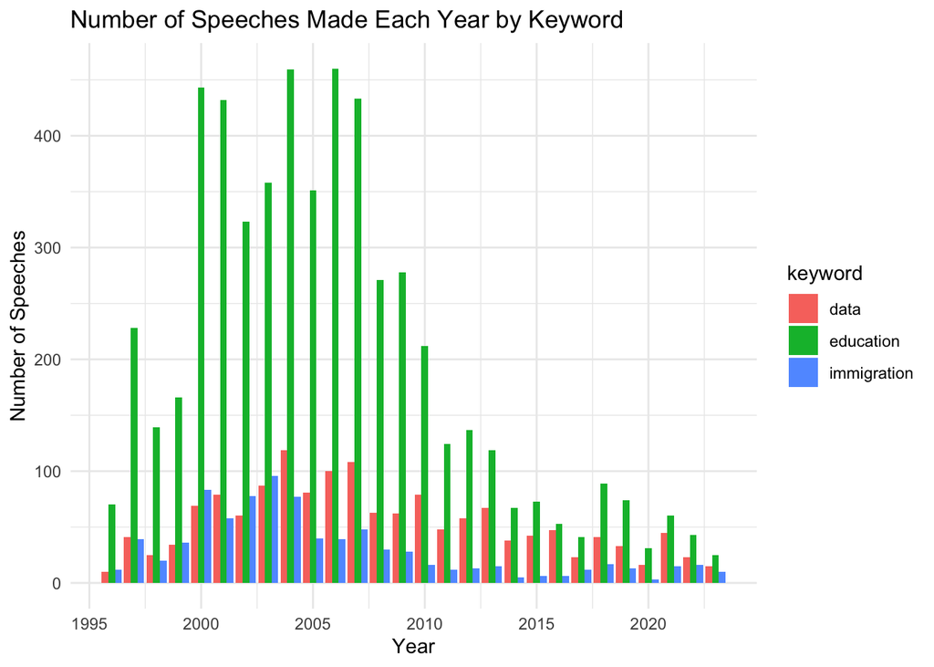

```r
library(tidyverse)
library(rvest)
library(magick)

keywords <- c("education","immigration", "data")

search1 <- read_html(paste0("https://datalandscapes.online/scrapeable/speeches.php?search=", keywords[1])) %>%
  html_elements(".speech_summary") %>%
  html_text2() %>%
  tibble(keyword = keywords[1],
         results = .) %>%
  separate(results, into = c("year", "num_speeches"), sep = "--") %>%
  mutate(num_speeches = parse_number(num_speeches),
         year = parse_number(year))

search2 <- read_html(paste0("https://datalandscapes.online/scrapeable/speeches.php?search=", keywords[2])) %>%
  html_elements(".speech_summary") %>%
  html_text2() %>%
  tibble(keyword = keywords[2],
         results = .) %>%
  separate(results, into = c("year", "num_speeches"), sep = "--") %>%
  mutate(num_speeches = parse_number(num_speeches),
         year = parse_number(year))

search3 <- read_html(paste0("https://datalandscapes.online/scrapeable/speeches.php?search=", keywords[3])) %>%
  html_elements(".speech_summary") %>%
  html_text2() %>%
  tibble(keyword = keywords[3],
         results = .) %>%
  separate(results, into = c("year", "num_speeches"), sep = "--") %>%
  mutate(num_speeches = parse_number(num_speeches),
         year = parse_number(year))


combined_search <- bind_rows(search1,search2,search3)

speeches_governments <- read_csv("https://docs.google.com/spreadsheets/d/e/2PACX-1vRHTFJcFmsIkjaFUCEwFWASaBOAR4X2Upx66C5Bhgc_WNc2JxxdRbbvyoewmvt_EjNdCNZZzzkENwLg/pub?gid=0&single=true&output=csv")

speech_data <- left_join(combined_search, speeches_governments, by = "year")


speech_data_plot <- speech_data %>%
  ggplot(aes(x = year, y = num_speeches, fill = keyword)) +
  geom_bar(stat = "identity", position = "dodge") +
  labs(title = "Number of Speeches Made Each Year by Keyword",
       x = "Year",
       y = "Number of Speeches") +
  theme_minimal()

speech_data_plot
```

The visualization illustrates the annual frequency of speeches on education, immigration, and data topics, showcasing trends and variations over time.

## Learning reflection

From the Module 5: Creating data from digital sources, I learned to how to use web scraping to source data, write SQL queries to join tables, combine data from different tables, develop strategies to combine data from different sources, manipulate data involving dates and times, and analyse text data using {stringr} and {dplyr}.I learned the significance of web scraping in sourcing data from digital platforms. Through this technique, I discovered the power of automating data collection from various online sources, enabling access to a wide array of valuable information for analysis and decision-making.

Moving forward, I’m particularly curious about delving deeper into the realm of data integration and manipulation. Exploring advanced techniques for combining data from disparate sources, such as APIs or databases, intrigues me.

## Self review

Reflecting on the completion of the five projects, I have undoubtedly honed my skills in data analysis and visualization through the utilization of various R packages such as {magick}, {tidyverse}, and {ggplot2}. By engaging with these tools, I’ve developed proficiency in generating static and dynamic visualizations, which not only enhance data interpretation but also facilitate effective communication of insights. Moreover, I’ve acquired the ability to manipulate and create new variables and data tables, enabling me to structure and organize data in a manner conducive to analysis. These skills align closely with the course learning outcomes for STATS 220, particularly in terms of mastering techniques for data manipulation, visualization, and analysis using statistical software like R.